# Data reading

# Generalization of discretization

Let's try to understand better the behavior generalizing this graph

```
We have 3656 array elems with a 0 interactions
We have 2817 array elems with interactions in (0, 1]
We have 12497 array elems with interactions in (1, 10]
We have 5814 array elems with interactions in (10, 20]
We have 2745 array elems with interactions in (20, 30]
We have 1436 array elems with interactions in (30, 40]
We have 780 array elems with interactions in (40, 50]
We have 470 array elems with interactions in (50, 60]
We have 256 array elems with interactions in (60, 70]
We have 141 array elems with interactions in (70, 80]
We have 95 array elems with interactions in (80, 90]
We have 57 array elems with interactions in (90, 100]
We have 147 array elems with interactions in (100, 1000]
```

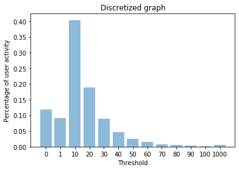

```
(array([ 3656,  2817, 12497,  5814,  2745,  1436,   780,   470,   256,
          141,    95,    57,   147]),
 array([0.11827505, 0.09113261, 0.40428974, 0.18808838, 0.08880334,
        0.04645595, 0.02523374, 0.01520494, 0.00828184, 0.00456148,
        0.00307334, 0.001844  , 0.00475559]))
```

```python
t_list = [0, 1, 10, 20, 30, 40, 50, 60, 70, 80, 90, 100, 1000]
plot_popularity_discretized(user_act, t_list, y_label="Percentage of user activity")
```

Most of the user have an activity level that is less then 20 interactions, and for many, we have only 1 interactions

```
We have 3218 array elems with a 0 interactions
We have 2008 array elems with interactions in (0, 1]
We have 7042 array elems with interactions in (1, 10]
We have 2201 array elems with interactions in (10, 20]
We have 1086 array elems with interactions in (20, 30]
We have 617 array elems with interactions in (30, 40]
We have 429 array elems with interactions in (40, 50]
We have 332 array elems with interactions in (50, 60]
We have 219 array elems with interactions in (60, 70]
We have 200 array elems with interactions in (70, 80]
We have 129 array elems with interactions in (80, 90]
We have 134 array elems with interactions in (90, 100]
We have 880 array elems with interactions in (100, 1000]
```

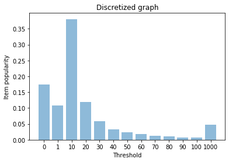

```
(array([3218, 2008, 7042, 2201, 1086,  617,  429,  332,  219,  200,  129,
         134,  880]),
 array([0.17399297, 0.10856988, 0.38075155, 0.11900514, 0.05871857,
        0.03336037, 0.02319546, 0.0179508 , 0.01184104, 0.01081373,
        0.00697486, 0.0072452 , 0.04758043]))
```

```python
plot_popularity_discretized(pop_items, t_list, y_label="Item popularity")
```

Some items are highly popular as we can seen, while this behaviour was not present for waht concerns the users. However, even in this case, we have a significant amount of items with ratings in (1, 10]

# Joint analysis: user activity=1. What did they like?

```python
user_act = (URM_all > 0).sum(axis=1)
user_act_unsorted = np.array(user_act).squeeze()
user_act_unsorted
```

```
array([  7,   6,  10, ...,  34,   5, 256])
```

```python
user_who_gave_1_like = np.where(user_act_unsorted == 1, user_act_unsorted, 0)
index_list = []
for i in range(0, user_who_gave_1_like.size):
    if user_who_gave_1_like[i] == 1:
        index_list.append(i)
index_arr = np.array(index_list)

item_liked = []
for index in index_arr:
    item_liked.append(URM_all[index, :].indices[0])
item_liked_arr = np.array(item_liked)
item_liked_arr.size
```

```
2817
```

```python
uniques = np.unique(item_liked_arr)
item_liked_arr.size - uniques.size
```

```
1143
```

```python
pop_items = get_popular_items(URM_all, popular_threshold=100)
pop_items.size
```

```
880
```

```python
mask = np.in1d(item_liked_arr, pop_items)
pop_item_recommended = item_liked_arr[mask]
pop_item_recommended.size
```

```
1496
```

#### Half of them are really popular! Let's see if some of them are unpopular.

```python
unpop_items = get_unpopular_items(URM_all, 1)
mask = np.in1d(item_liked_arr, unpop_items)
unpop_item_recommended = item_liked_arr[mask]
unpop_item_recommended.size
```

```
25
```

##### 25 of them are due to the fact that only that user rated that item! They are somehow noise.